# Evaluation_75x25

Kento Okuyama

2023-11-30

## (very) Brief introduction

In this document, we evaluate the implementation of our frequentist implementation of the non-linear regime-switching state-space (RSSS) model estimation based on simulated data. Our implementation is a special case in which the regime-switch occurs only in one direction (i.e., there’s no switch back). Our parameter optimization consists of 300 iteration steps based on Adam and 30 initializations of the starting parameter values.

In our implementation, our objective function **sumLik** is maximized based on the gradient vector and Adam. For evaluation purpose, we also have the score function **delta**. This is simply calculated as the summed squared error of the one-step-ahead (of the last observed time points) prediction of our intra-individual latent variables. Further, we also have **sensitivity** and **specificity** based on the one-step-ahead regime prediction results.

### N=75, T=25

```
## <environment: R_GlobalEnv>
```

```
## <environment: R_GlobalEnv>
```

```
## <environment: R_GlobalEnv>
```

Before starting the evaluation of our estimated results, let’s take a look at the simulated data. We are particularly interested in the regime-switch occurence. We will summarize the percentage of subjects who made a regime switch in each of simulated realizations.

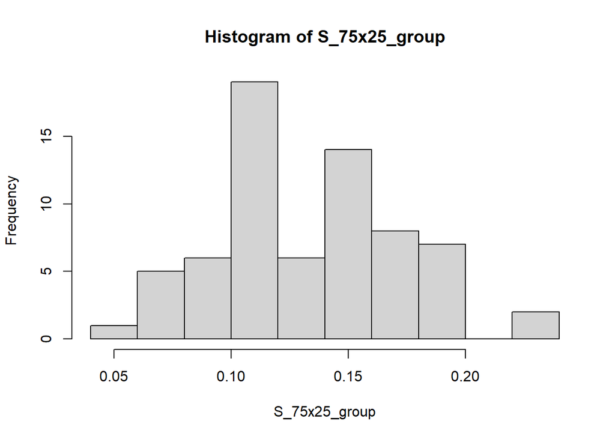

```
##    Min. 1st Qu.  Median    Mean 3rd Qu.    Max.
## 0.05333 0.10667 0.13333 0.13647 0.16333 0.24000
```

First, we check the distribution of the resulting **sumLik** in log scale.

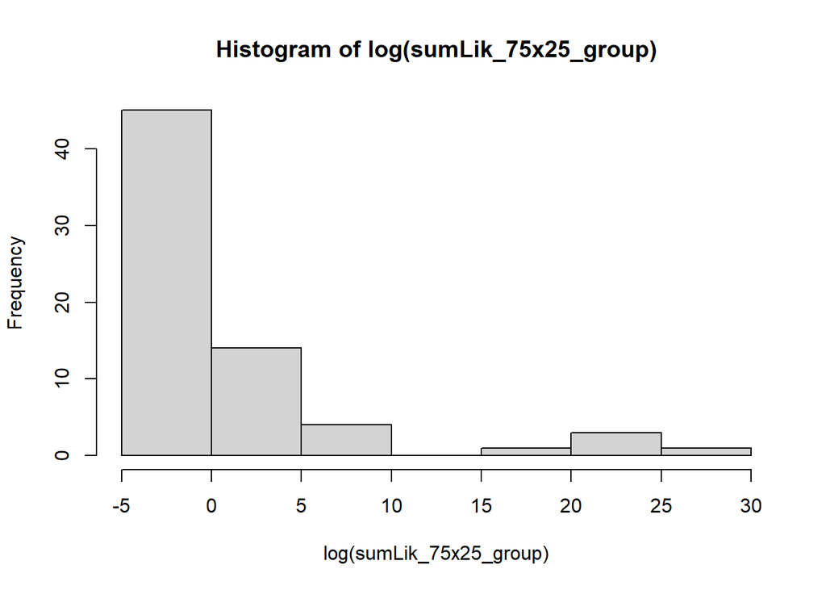

```
##    Min. 1st Qu.  Median    Mean 3rd Qu.    Max.
## -3.9265 -3.2483 -2.7027  0.5083  1.7091 25.0186
```

It seems like there are a few instances which has much higher **sumLik** than others.

Second, we check the distribution of the resulting **delta** in log scale.

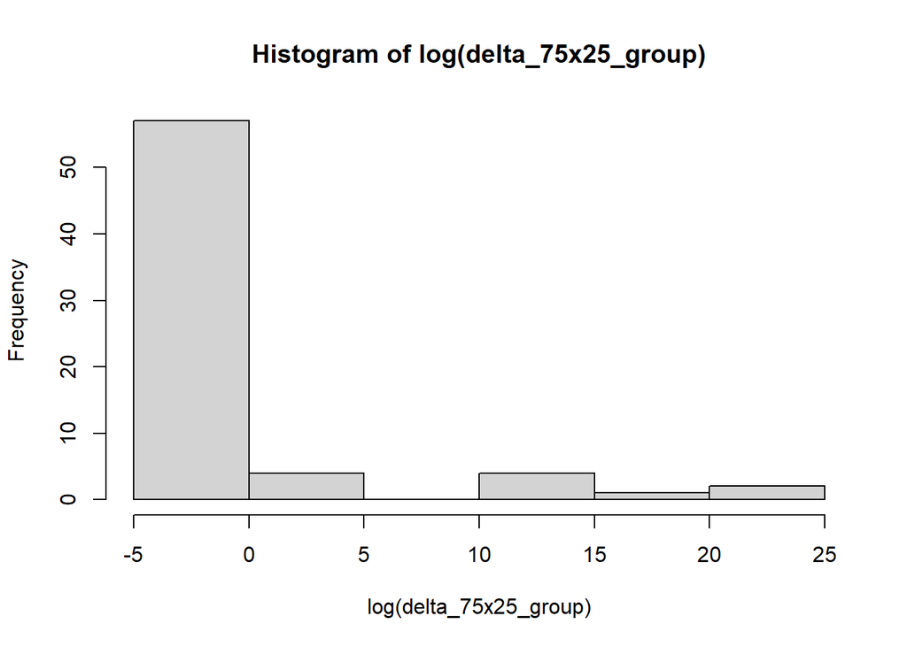

```
##    Min. 1st Qu.  Median    Mean 3rd Qu.    Max.
## -1.8977 -1.5820 -1.3089  0.7536 -1.0704 24.1109
```

Please note that we prefer a smaller value as it is calculated based on the prediction error.

Next, we turn our attention to how the **sumLik** and **delta** correlate (in log scale). Intuitively, we expect the negative correlation so that higher **sumLik** (maximized likelihood) relates to smaller **delta** (smaller prediction error).

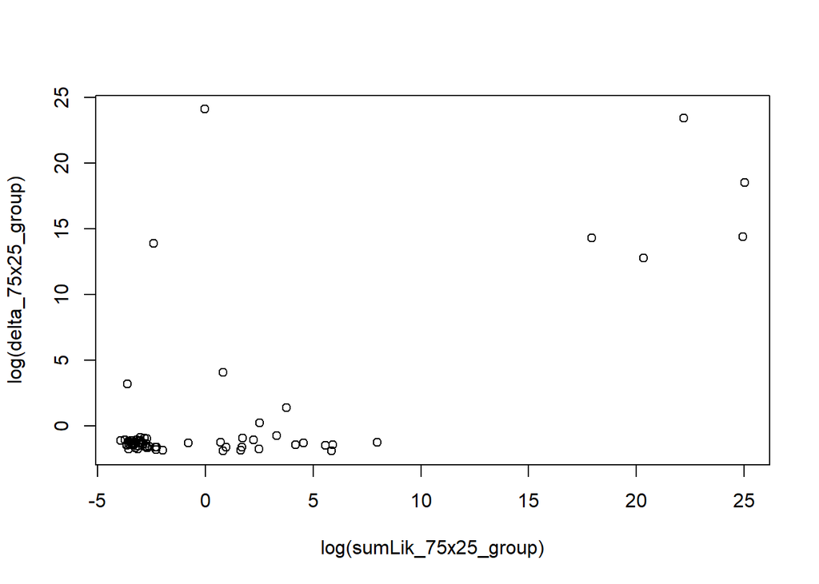

```
## [1] 0.7008923
```

Then, we check the distribution of **sensitivity** and **specificity**. First for **sensitivity**

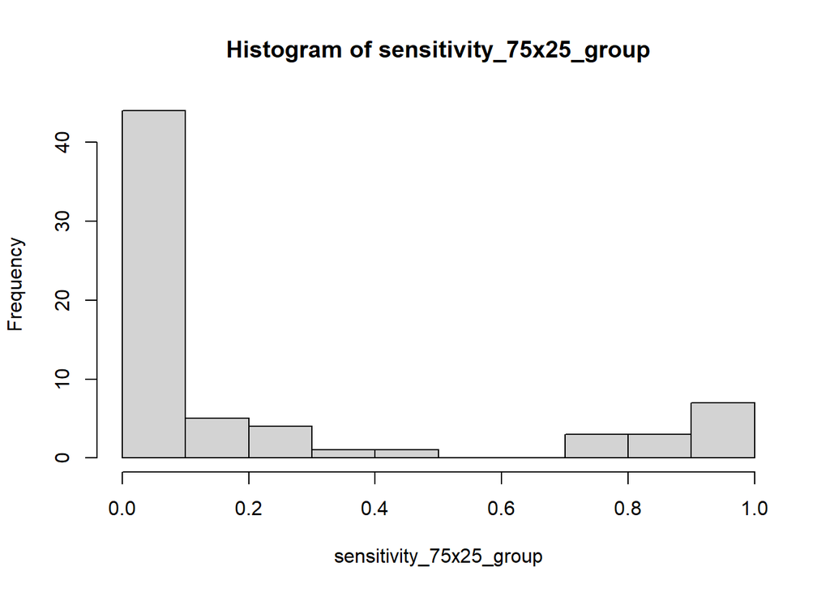

```
##    Min. 1st Qu.  Median    Mean 3rd Qu.    Max.
##  0.0000  0.0000  0.0000  0.2158  0.2625  1.0000
```

And for **specificity**

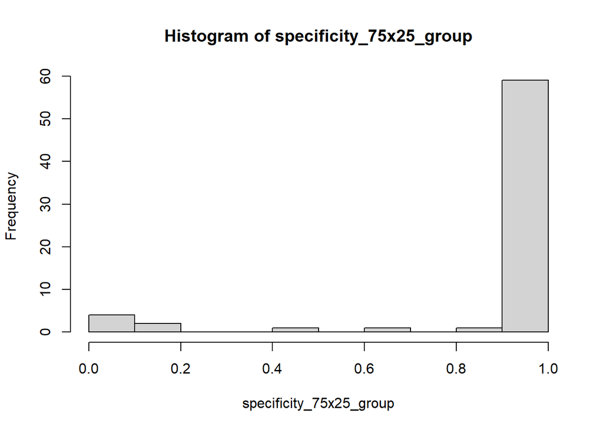

```
##    Min. 1st Qu.  Median    Mean 3rd Qu.    Max.
##  0.0000  1.0000  1.0000  0.9004  1.0000  1.0000
```

We can also check the correlation between **sensitivity** and **specificity**.

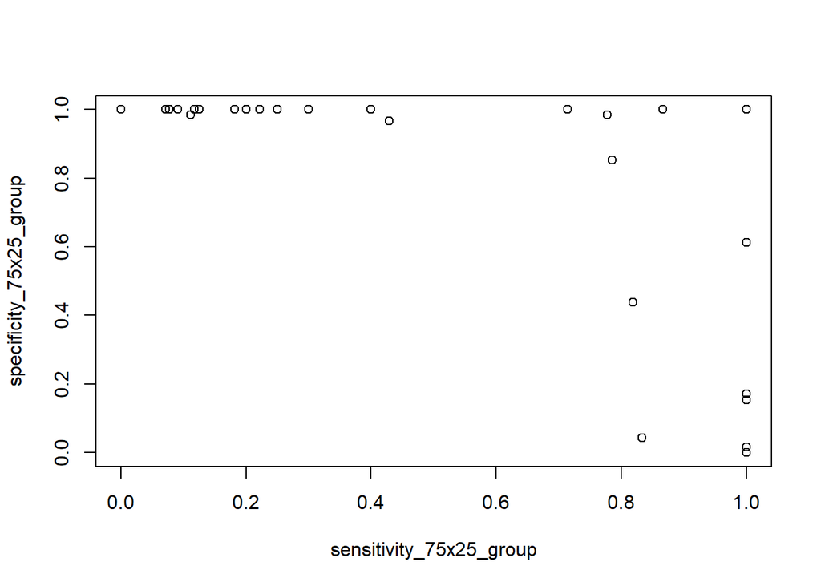

```
## [1] -0.759234
```

Finally we examine our parameter estimation. The distribution of parameter estimation are shown below. True parameter values are in parenthesis.

```
##    B11_1 (.2)          B11_2 (.3)         B12_1 (-.1)       B12_2 (-.2)
##  Min.   :-0.005404   Min.   :-0.001439   Min.   :-0.5337   Min.   :-0.41925
##  1st Qu.: 0.093967   1st Qu.: 0.123418   1st Qu.:-0.2495   1st Qu.:-0.23280
##  Median : 0.142264   Median : 0.197222   Median :-0.1539   Median :-0.15420
##  Mean   : 0.162761   Mean   : 0.219868   Mean   :-0.1757   Mean   :-0.15939
##  3rd Qu.: 0.188304   3rd Qu.: 0.289994   3rd Qu.:-0.1025   3rd Qu.:-0.07940
##  Max.   : 0.521555   Max.   : 0.588488   Max.   : 0.1217   Max.   : 0.06142
##   B21d_1 (.8)      B21d_2 (.8)      B22d_1 (.4)        B22d_2 (.4)
##  Min.   :0.6219   Min.   :0.5365   Min.   :-0.01309   Min.   :-0.01860
##  1st Qu.:0.7894   1st Qu.:0.7937   1st Qu.: 0.10007   1st Qu.: 0.04868
##  Median :0.8452   Median :0.8524   Median : 0.22768   Median : 0.18078
##  Mean   :0.8369   Mean   :0.8313   Mean   : 0.21450   Mean   : 0.19088
##  3rd Qu.:0.8878   3rd Qu.:0.8916   3rd Qu.: 0.31155   3rd Qu.: 0.31369
##  Max.   :1.0193   Max.   :1.0612   Max.   : 0.47661   Max.   : 0.47765
##    B31_1 (.1)         B31_2 (.1)        B32_1 (-.1)        B31_2 (-.1)
##  Min.   :-0.43691   Min.   :-0.47400   Min.   :-0.27585   Min.   :-0.509739
##  1st Qu.:-0.01903   1st Qu.:-0.01190   1st Qu.:-0.13371   1st Qu.:-0.122789
##  Median : 0.06290   Median : 0.06645   Median :-0.07279   Median :-0.056207
##  Mean   : 0.08031   Mean   : 0.08214   Mean   :-0.06108   Mean   :-0.066525
##  3rd Qu.: 0.18776   3rd Qu.: 0.16748   3rd Qu.:-0.01282   3rd Qu.:-0.008669
##  Max.   : 0.55698   Max.   : 0.52040   Max.   : 0.37832   Max.   : 0.148865
##    Lmdd_1 (1)   Lmdd_2 (0)  Lmdd_3 (.4)       Lmdd_4 (0)  Lmdd_5 (.8)
##  Min.   :1    Min.   :0    Min.   :0.2613   Min.   :0    Min.   :0.5086
##  1st Qu.:1    1st Qu.:0    1st Qu.:0.5625   1st Qu.:0    1st Qu.:0.7992
##  Median :1    Median :0    Median :0.7866   Median :0    Median :0.9170
##  Mean   :1    Mean   :0    Mean   :0.8014   Mean   :0    Mean   :0.9324
##  3rd Qu.:1    3rd Qu.:0    3rd Qu.:1.0388   3rd Qu.:0    3rd Qu.:1.0890
##  Max.   :1    Max.   :0    Max.   :1.3534   Max.   :0    Max.   :1.3701
##    Lmdd_6 (0)   Lmdd_7 (0)   Lmdd_8 (1)   Lmdd_9 (0)  Lmdd_10 (.5)
##  Min.   :0    Min.   :0    Min.   :1    Min.   :0    Min.   :0.3913
##  1st Qu.:0    1st Qu.:0    1st Qu.:1    1st Qu.:0    1st Qu.:0.5793
##  Median :0    Median :0    Median :1    Median :0    Median :0.7721
##  Mean   :0    Mean   :0    Mean   :1    Mean   :0    Mean   :0.8298
##  3rd Qu.:0    3rd Qu.:0    3rd Qu.:1    3rd Qu.:0    3rd Qu.:1.1353
##  Max.   :0    Max.   :0    Max.   :1    Max.   :0    Max.   :1.3577
##   Lmdd_11 (0) Lmdd_12 (1.2)      Qd_1 (.2)          Qd_2 (.2)
##  Min.   :0    Min.   :0.6469   Min.   :0.001000   Min.   :0.001000
##  1st Qu.:0    1st Qu.:0.9986   1st Qu.:0.002667   1st Qu.:0.003031
##  Median :0    Median :1.1737   Median :0.172604   Median :0.171522
##  Mean   :0    Mean   :1.1236   Mean   :0.103564   Mean   :0.104190
```

[output cut: 8 more lines]

```
##  Max.   :0.37834   Max.   :0.37791   Max.   :0.37806   Max.   :0.37911
##    Rd_5 (.3)         Rd_6 (.3)        gamma1 (3.5)    gamma2_1 (1)
##  Min.   :0.01943   Min.   :0.04980   Min.   :4.104   Min.   :-0.08532
##  1st Qu.:0.06890   1st Qu.:0.09012   1st Qu.:4.122   1st Qu.: 0.59330
##  Median :0.37240   Median :0.37177   Median :4.125   Median : 0.93409
##  Mean   :0.24871   Mean   :0.25637   Mean   :4.242   Mean   : 1.02507
##  3rd Qu.:0.37479   3rd Qu.:0.37384   3rd Qu.:4.376   3rd Qu.: 1.41657
##  Max.   :0.37839   Max.   :0.37775   Max.   :4.622   Max.   : 2.34105
##   gamma2_2 (1)
##  Min.   :0.1315
##  1st Qu.:0.5187
##  Median :0.8229
##  Mean   :0.9518
##  3rd Qu.:1.2264
##  Max.   :2.8608
```

Finally, we check the rate of regime-switch prediction by the time of the final prediction which we call the dropout prediction rate.

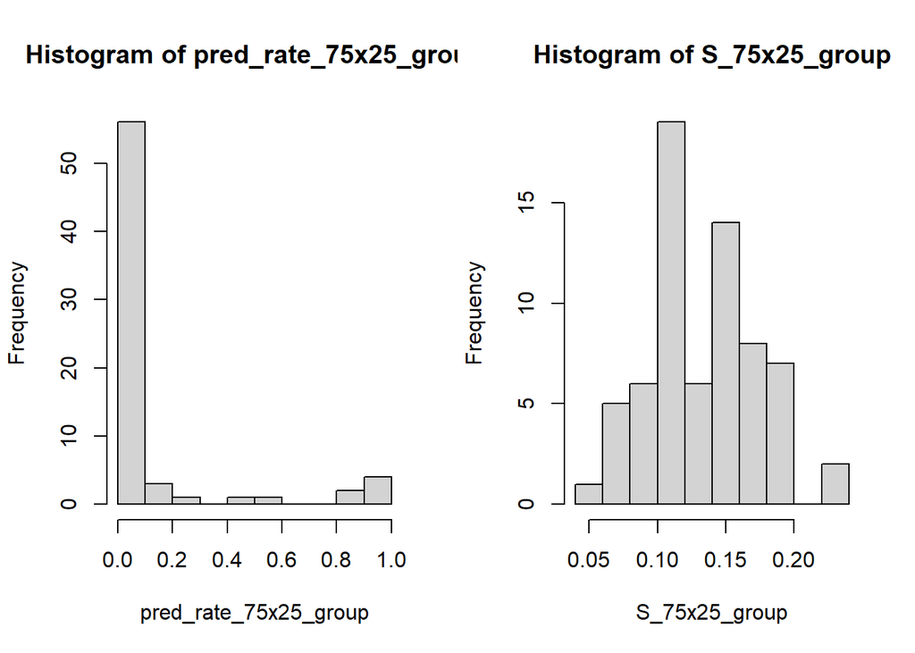

```
##    Min. 1st Qu.  Median    Mean 3rd Qu.    Max.
##  0.0000  0.0000  0.0000  0.1167  0.0400  1.0000
```

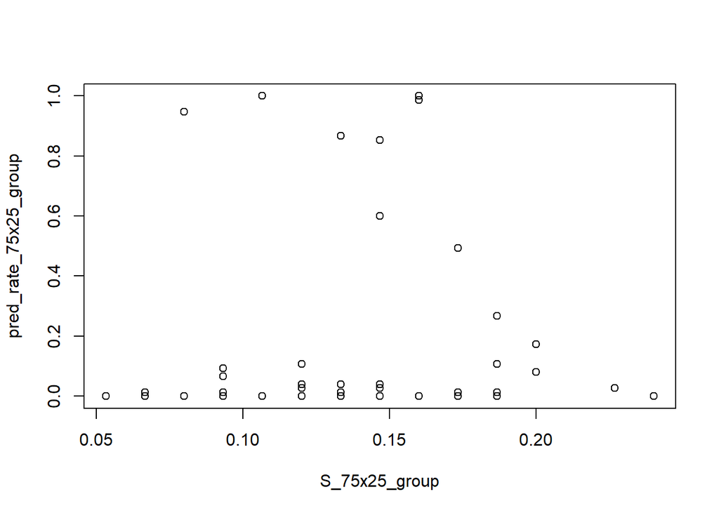

```
## [1] 0.02900294
```

Then, we check the distribution of **sensitivity** and **specificity**. First for **sensitivity**

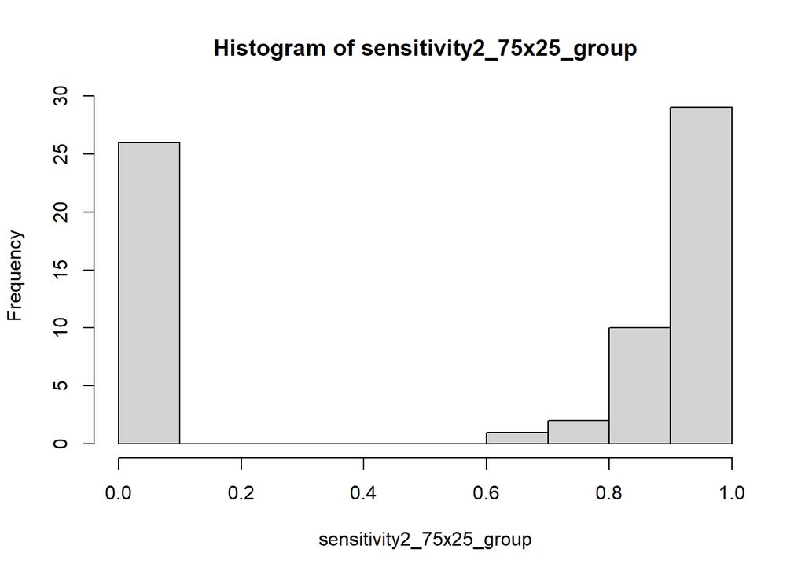

```
##    Min. 1st Qu.  Median    Mean 3rd Qu.    Max.
##  0.0000  0.0000  0.8750  0.5788  1.0000  1.0000
```

And for **specificity**

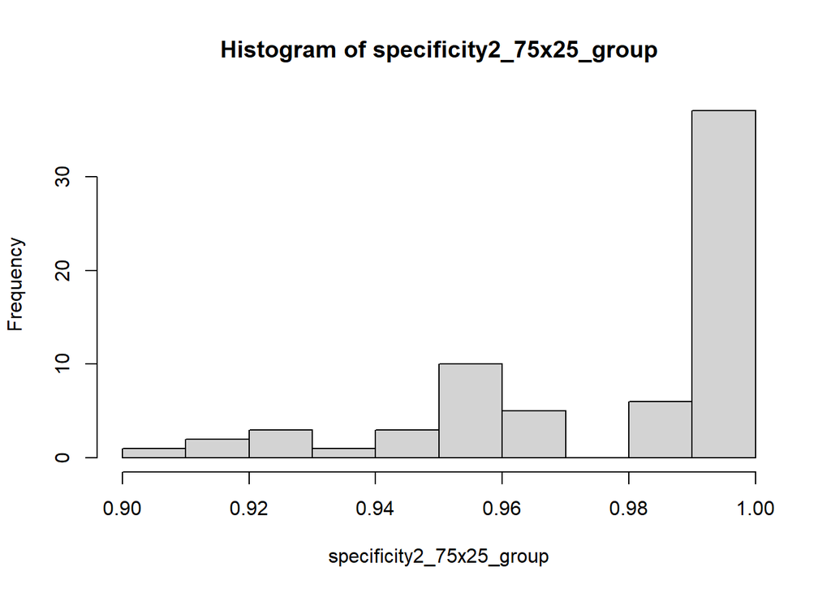

```
##    Min. 1st Qu.  Median    Mean 3rd Qu.    Max.
##  0.9000  0.9545  1.0000  0.9788  1.0000  1.0000
```

We can also check the correlation between **sensitivity** and **specificity**.

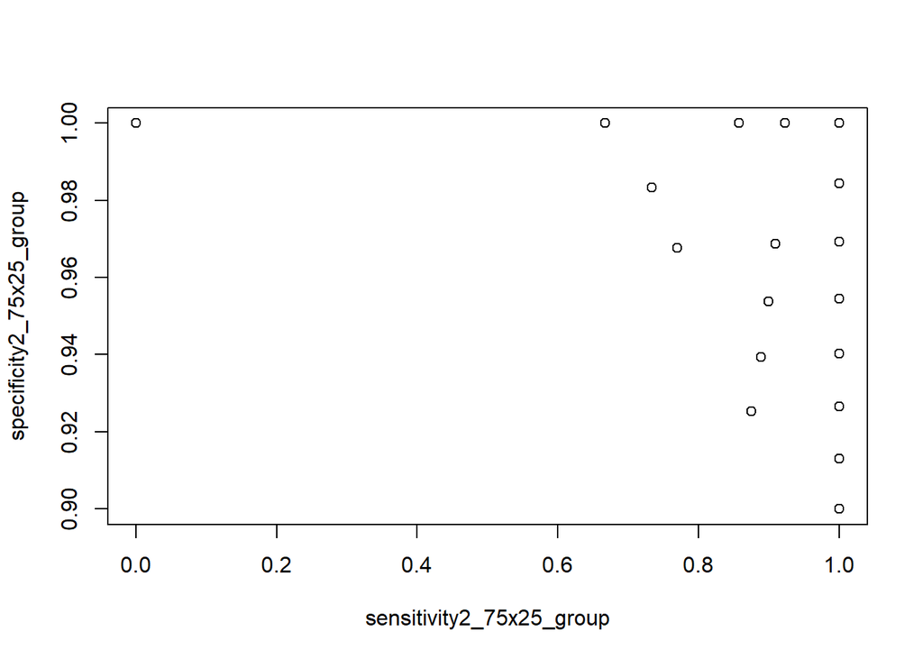

```
## [1] -0.6311664
```